# Titanic Project

Using Kaggle data about the unlucky passengers of RMS Titanic, we'll try to investigate what factors might be related to survival of some of the passengers. We'll first import necessary packages, read the data, and verify the data is read.

## Importing Packages

```python
# importing all necessary packages and functions.
import csv
from datetime import datetime
import numpy as np
import pandas as pd
from IPython.display import display
import matplotlib.pyplot as plt
%matplotlib inline

# kernel option to see value of multiple statements

from IPython.core.interactiveshell import InteractiveShell
InteractiveShell.ast_node_interactivity = "all"
```

## Reading Data

```python
# reading data from csv file

titanic_raw = pd.read_csv('titanic-data.csv')
```

## Titanic Data from Kaggle

```python
# verifying that data is read

print "Number of passengers= " + str(len(titanic_raw.Name.unique()))
titanic_raw.head()
print "..."
titanic_raw.tail()

# summarizing data
print "\nSummary of raw data"
titanic_raw.describe()
```

```
Number of passengers= 891
```

|  | PassengerId | Survived | Pclass | Name | Sex | Age | SibSp | Parch | Ticket | Fare | Cabin | Embarked |
| --- | --- | --- | --- | --- | --- | --- | --- | --- | --- | --- | --- | --- |
| 0 | 1 | 0 | 3 | Braund, Mr. Owen Harris | male | 22.0 | 1 | 0 | A/5 21171 | 7.2500 | NaN | S |
| 1 | 2 | 1 | 1 | Cumings, Mrs. John Bradley (Florence Briggs Th... | female | 38.0 | 1 | 0 | PC 17599 | 71.2833 | C85 | C |
| 2 | 3 | 1 | 3 | Heikkinen, Miss. Laina | female | 26.0 | 0 | 0 | STON/O2. 3101282 | 7.9250 | NaN | S |
| 3 | 4 | 1 | 1 | Futrelle, Mrs. Jacques Heath (Lily May Peel) | female | 35.0 | 1 | 0 | 113803 | 53.1000 | C123 | S |
| 4 | 5 | 0 | 3 | Allen, Mr. William Henry | male | 35.0 | 0 | 0 | 373450 | 8.0500 | NaN | S |

```
...
```

|  | PassengerId | Survived | Pclass | Name | Sex | Age | SibSp | Parch | Ticket | Fare | Cabin | Embarked |
| --- | --- | --- | --- | --- | --- | --- | --- | --- | --- | --- | --- | --- |
| 886 | 887 | 0 | 2 | Montvila, Rev. Juozas | male | 27.0 | 0 | 0 | 211536 | 13.00 | NaN | S |
| 887 | 888 | 1 | 1 | Graham, Miss. Margaret Edith | female | 19.0 | 0 | 0 | 112053 | 30.00 | B42 | S |
| 888 | 889 | 0 | 3 | Johnston, Miss. Catherine Helen "Carrie" | female | NaN | 1 | 2 | W./C. 6607 | 23.45 | NaN | S |
| 889 | 890 | 1 | 1 | Behr, Mr. Karl Howell | male | 26.0 | 0 | 0 | 111369 | 30.00 | C148 | C |
| 890 | 891 | 0 | 3 | Dooley, Mr. Patrick | male | 32.0 | 0 | 0 | 370376 | 7.75 | NaN | Q |

```
Summary of raw data
```

|  | PassengerId | Survived | Pclass | Age | SibSp | Parch | Fare |
| --- | --- | --- | --- | --- | --- | --- | --- |
| count | 891.000000 | 891.000000 | 891.000000 | 714.000000 | 891.000000 | 891.000000 | 891.000000 |
| mean | 446.000000 | 0.383838 | 2.308642 | 29.699118 | 0.523008 | 0.381594 | 32.204208 |
| std | 257.353842 | 0.486592 | 0.836071 | 14.526497 | 1.102743 | 0.806057 | 49.693429 |
| min | 1.000000 | 0.000000 | 1.000000 | 0.420000 | 0.000000 | 0.000000 | 0.000000 |
| 25% | 223.500000 | 0.000000 | 2.000000 | 20.125000 | 0.000000 | 0.000000 | 7.910400 |
| 50% | 446.000000 | 0.000000 | 3.000000 | 28.000000 | 0.000000 | 0.000000 | 14.454200 |
| 75% | 668.500000 | 1.000000 | 3.000000 | 38.000000 | 1.000000 | 0.000000 | 31.000000 |
| max | 891.000000 | 1.000000 | 3.000000 | 80.000000 | 8.000000 | 6.000000 | 512.329200 |

# Question: Which factors, if any, made Titanic passengers more likely to survive?

We'll approach this question by treating *Survived* column as a dependent variable, and investigate variables *Pclass*, *Sex*, and *Age* variables to see if there are any correlations between them and *Survived* variable.

## Data Wrangling

Let's first remove the columns we will not focus on, and check if there are any missing data points.

```python
# using drop to remove columns
titanic = titanic_raw.drop(titanic_raw.columns[[0,3,6,7,8,9,10,11]], axis=1)
print "\nColumns (variables) we will focus:"
titanic.head()

# counting NaN values to see if there is any missing data
titanic.isnull().sum(axis=0)
```

```
Columns (variables) we will focus:
```

|  | Survived | Pclass | Sex | Age |
| --- | --- | --- | --- | --- |
| 0 | 0 | 3 | male | 22.0 |
| 1 | 1 | 1 | female | 38.0 |
| 2 | 1 | 3 | female | 26.0 |
| 3 | 1 | 1 | female | 35.0 |
| 4 | 0 | 3 | male | 35.0 |

```
Survived      0
Pclass        0
Sex           0
Age         177
dtype: int64
```

We have missing values in *Age* column. We can drop these values if this will not create a bias, but for example what if almost all the values dropped are of passengers with a specific characteristic that changed their survival rate? It would probably damage our model. So these are the questions to be answered:

- Are the missing *Age* values meaningful in itself? (Only 12-18 age group are missing etc.)
- Do the *Pclass*, *Sex* or *Survived* variables in rows that include missing *Age* values show a pattern different than general passenger data? (As in the above hypothetical scenario)

We first look at *Age* variable in itself.

```
count    714.000000
mean      29.699118
std       14.526497
min        0.420000
25%       20.125000
50%       28.000000
75%       38.000000
max       80.000000
Name: Age, dtype: float64
```

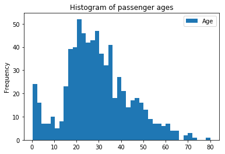

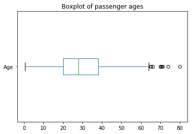

```python
# creating an age histogram
titanic.plot.hist(y=["Age"], title="Histogram of passenger ages", bins=40)
titanic.plot.box(y=["Age"], title="Boxplot of passenger ages", vert=False)
titanic["Age"].describe()
```

We don't see any incredible nature in *Age* variable. One interesting thing is low ratio of children compared to the ratio in an arbitrary population. We can assume this might be attributed to the fact that a long voyage in a cruise is not feasible for children (they neither would get permission to go alone nor would raise enough money by themselves).

Let's look at the rows with missing *Age* data. For this purpose we will define a new data frame and remove the *Age* column as they will be NaN values. Then we will try to see **if there is any pattern in *Pclass*, *Sex* or *Survived* paramaters that differs from main dataset.**

```python
# defining a new dataframe
titanic_nan = titanic[pd.isnull(titanic['Age'])]

# dropping Age column (all NaN)
titanic_nan = titanic_nan.drop(titanic_nan.columns[3], axis=1)

# looking at the difference in distribution of Pclass in different Survived categories
pd.crosstab(titanic["Pclass"], titanic["Survived"], normalize = "columns")
pd.crosstab(titanic_nan["Pclass"], titanic_nan["Survived"], normalize = "columns")
```

| Survived Pclass | 0 | 1 |
| --- | --- | --- |
| 1 | 0.145719 | 0.397661 |
| 2 | 0.176685 | 0.254386 |
| 3 | 0.677596 | 0.347953 |

| Survived Pclass | 0 | 1 |
| --- | --- | --- |
| 1 | 0.128 | 0.269231 |
| 2 | 0.056 | 0.076923 |
| 3 | 0.816 | 0.653846 |

We see the only considerable difference is that passengers without an *Age* value are more dominantly 3rd class passengers than they are in whole dataset, presumably due to lack of ID or self-knowledge.

```python
# looking at the difference in distribution of Survived in different Pclass categories

pd.crosstab(titanic["Pclass"], titanic["Survived"], normalize = "index")
pd.crosstab(titanic_nan["Pclass"], titanic_nan["Survived"], normalize = "index")
```

| Survived Pclass | 0 | 1 |
| --- | --- | --- |
| 1 | 0.370370 | 0.629630 |
| 2 | 0.527174 | 0.472826 |
| 3 | 0.757637 | 0.242363 |

| Survived Pclass | 0 | 1 |
| --- | --- | --- |
| 1 | 0.533333 | 0.466667 |
| 2 | 0.636364 | 0.363636 |
| 3 | 0.750000 | 0.250000 |

We see that while it is almost the same in 3rd class, in 1st and 2nd classes Survival Rate drops in the passengers without an *Age* value. We take note of this.

```python
# looking at the difference in distribution of Sex in different Survived categories

pd.crosstab(titanic["Sex"], titanic["Survived"], normalize = "columns")
pd.crosstab(titanic_nan["Sex"], titanic_nan["Survived"], normalize = "columns")
```

| Survived Sex | 0 | 1 |
| --- | --- | --- |
| female | 0.147541 | 0.681287 |
| male | 0.852459 | 0.318713 |

| Survived Sex | 0 | 1 |
| --- | --- | --- |
| female | 0.136 | 0.692308 |
| male | 0.864 | 0.307692 |

It can be said that the difference is negligible.

```python
# looking at the difference in distribution of Survived in different Sex categories

pd.crosstab(titanic["Sex"], titanic["Survived"], normalize = "index")
pd.crosstab(titanic_nan["Sex"], titanic_nan["Survived"], normalize = "index")
```

| Survived Sex | 0 | 1 |
| --- | --- | --- |
| female | 0.257962 | 0.742038 |
| male | 0.811092 | 0.188908 |

| Survived Sex | 0 | 1 |
| --- | --- | --- |
| female | 0.320755 | 0.679245 |
| male | 0.870968 | 0.129032 |

For our purposes, we will ignore the missing values in *Age* variable as we still have 714 data point when we include it in a particular analysis, and 891 when we don't. We will accept that missing *Age* values do not affect the relationship of *Age*, *Pclass* or *Sex* variable with the dependent variable *Survived*; with the disclaimer that the effect not having an *Age* does have on *Survived* variable must be analyzed further.

Also, we'll separate the *Age* variable to groups and create a variable called *Age_Grouped* as it will not be demonstrative to use *Age* as it is.

```python
# creating age groups
age_groups = [0, 6, 12, 18, 65, 100]
age_group_names = ['0-6', '6-12', '12-18', '18-65', '65+']
titanic["Age_Grouped"] = pd.cut(titanic["Age"], age_groups, labels=age_group_names)
```

## Exploratory Data Analysis

We'll first create one-way frequency tables to get an initial idea of what might be correlated with *Survived* variable.

```python
# creating one-way frequency tables
pd.crosstab(titanic["Pclass"], titanic["Survived"], margins = True)
print "Passengers according to their Ticket class\n"
pd.crosstab(titanic["Sex"], titanic["Survived"], margins = True)
print "Passengers according to their Sex\n"
pd.crosstab(titanic["Age_Grouped"], titanic["Survived"], margins = True)
print "Passengers according to their Age\n"
```

| Survived Pclass | 0 | 1 | All |
| --- | --- | --- | --- |
| 1 | 80 | 136 | 216 |
| 2 | 97 | 87 | 184 |
| 3 | 372 | 119 | 491 |
| All | 549 | 342 | 891 |

```
Passengers according to their Ticket class
```

| Survived Sex | 0 | 1 | All |
| --- | --- | --- | --- |
| female | 81 | 233 | 314 |
| male | 468 | 109 | 577 |
| All | 549 | 342 | 891 |

```
Passengers according to their Sex
```

| Survived Age_Grouped | 0 | 1 | All |
| --- | --- | --- | --- |
| 0-6 | 14 | 33 | 47 |
| 6-12 | 15 | 7 | 22 |
| 12-18 | 40 | 30 | 70 |
| 18-65 | 348 | 219 | 567 |
| 65+ | 7 | 1 | 8 |
| All | 424 | 290 | 714 |

```
Passengers according to their Age
```

What are the initial thoughts here? Looking at *Pclass* variable, we see that 63% of 1st class passengers survived, while it is 47% in 2nd class. Finally in 3rd class we see that only 24% of passengers survived.

Looking at passengers' *Sex*, survival rate drops from 74% in women to 19% in men.

In *Age_Grouped* variable, we see that for most groups survival ratio is close. Only in age group 0-6 survival increases, and we note this down. While it also seems to drop in 65+ age group, it might be said 8 data points are too few to draw conclusions.

We'll now focus on *Pclass* and *Sex* variables with a two-way frequency table to see if we can draw further findings from survival ratio.

```python
# two-way frequency table for Sex and Pclass variables
pd.crosstab((titanic["Sex"], titanic["Pclass"]), titanic["Survived"], margins = True)
print "Passengers according to their Sex and Pclass\n"

# normalizing each row for easier analysis
pd.crosstab((titanic["Sex"], titanic["Pclass"]), titanic["Survived"], normalize = 'index')
print "Sex and Pclass data given as share of each row"
```

| Sex | Survived Pclass | 0 | 1 | All |
| --- | --- | --- | --- | --- |
| female | 1 | 3 | 91 | 94 |
|  | 2 | 6 | 70 | 76 |
|  | 3 | 72 | 72 | 144 |
| male | 1 | 77 | 45 | 122 |
|  | 2 | 91 | 17 | 108 |
|  | 3 | 300 | 47 | 347 |
| All |  | 549 | 342 | 891 |

[output not shown]

| Sex | Survived Pclass | 0 | 1 |
| --- | --- | --- | --- |
| female | 1 | 0.031915 | 0.968085 |
|  | 2 | 0.078947 | 0.921053 |
|  | 3 | 0.500000 | 0.500000 |
| male | 1 | 0.631148 | 0.368852 |
|  | 2 | 0.842593 | 0.157407 |
|  | 3 | 0.864553 | 0.135447 |

[output not shown]

As we go from 1st class to 3rd class, we see that survival ratio falls from 97% to 50% in women and from 37% to 14% in men. Remembering that 0-6 aged children survived more, while it might be true that "Women and children first" mostly applied; socioeconomic status also was related to survival rate of passengers. Why is that? Why passengers from 3rd class had a lower survival rate? Is it because 1st and 2nd class consist more women and children than in 3rd class? Or the *Class* has an independent correlation with *Survived*?

```python
pd.crosstab(titanic["Pclass"], titanic["Sex"], normalize = 'index')
```

| Sex Pclass | female | male |
| --- | --- | --- |
| 1 | 0.435185 | 0.564815 |
| 2 | 0.413043 | 0.586957 |
| 3 | 0.293279 | 0.706721 |

Lastly, even though it is out of our scope, we check the *Cabin* parameter to see if 3rd class passengers had an inherent disadvantage to reach the upmost deck where they could disembark.

```python
# checking the distribution of passengers to cabins

titanic_cabin = titanic_raw.drop(titanic_raw.columns[[0,1,3,4,5,6,7,8,9,11]], axis=1)
titanic_cabin['Cabinned'] = titanic_cabin['Cabin'].str[:1]
pd.crosstab(titanic_cabin["Pclass"], titanic_cabin["Cabinned"], margins = True)
```

| Cabinned Pclass | A | B | C | D | E | F | G | T | All |
| --- | --- | --- | --- | --- | --- | --- | --- | --- | --- |
| 1 | 15 | 47 | 59 | 29 | 25 | 0 | 0 | 1 | 176 |
| 2 | 0 | 0 | 0 | 4 | 4 | 8 | 0 | 0 | 16 |
| 3 | 0 | 0 | 0 | 0 | 3 | 5 | 4 | 0 | 12 |
| All | 15 | 47 | 59 | 33 | 32 | 13 | 4 | 1 | 204 |

Even though a great number of data points are missing, we see the general trend shows that going from A to G in *Cabin* means a higher *Pclass* value (lower socioeconomic status).

Now we check the layout of Titanic, and we see that going from A to G means that a passenger is located lower in Titanic, which probably decrease the chances of survival.

[figure not shown]

```python
# checking the actual layout of Titanic

from IPython.display import Image
Image(filename='titanic.jpg')
```

## Conclusion

Our limited analysis shows that females survived in a higher ratio regarding *Sex* variable. Furthermore, we had already noted 0-6 aged children had a higher survival rate.

Higher percentage of women in 1st and 2nd class, and higher distance from 3rd class cabins to upper deck might have caused the lower survival rate of 3rd class passengers.

At this point, we must note that correlation does not imply causation. For instance, 0-6 age children might have a higher survival rate just because their mothers or nannies had a higher survival rate, which affected them too (For further analysis *Parch* variable might be investigated). This means *Age* might not have any statistically significant relation to *Survived*. If we want to create hypotheses to test, we might say that a passenger had a higher chance of survival if she is a female or that passenger is travelling 1st class. Our intuition also suggests these hypotheses would be correct, but we must rely on statistics and data analysis rather than intuition.

## References

https://www.kaggle.com/c/titanic/data  
https://www.dataquest.io/blog/jupyter-notebook-tips-tricks-shortcuts/  
https://stackoverflow.com/questions/41906199/how-to-make-a-new-line-in-a-jupyter-markdown-cell  
https://stackoverflow.com/questions/13411544/delete-column-from-pandas-dataframe  
https://stackoverflow.com/questions/30059260/python-pandas-counting-the-number-of-missing-nan-in-each-row  
https://chrisalbon.com/python/pandas_crosstabs.html  
https://chrisalbon.com/python/pandas_binning_data.html  
https://stackoverflow.com/questions/14247586/python-pandas-how-to-select-rows-with-one-or-more-nulls-from-a-dataframe-without  
https://pandas.pydata.org/pandas-docs/stable/visualization.html  
https://s-media-cache-ak0.pinimg.com/originals/7a/e4/75/7ae475e74a634a502a3ff9f7daf17d6d.jpg